[output not shown]

## Computing the Sample Variance

Let’s read the Premier League heights data into R again (we will use this on and off for the next few weeks):

```r
pl <- read_csv("../data/premier_league.csv")
pl <- filter(pl, !is.na(height))
pl
```

```
## # A tibble: 640 × 5
##    player          team            bdate      height position
##    <chr>           <chr>           <date>      <dbl> <chr>
##  1 Adam Smith      AFC Bournemouth 1991-04-29    180 DF
##  2 Alex Scott      AFC Bournemouth 2003-08-21    178 MF
##  3 Antoine Semenyo AFC Bournemouth 2000-01-07    185 FW
##  4 Ben Greenwood   AFC Bournemouth 2003-02-20    180 DF
##  5 Cameron Plain   AFC Bournemouth 2001-09-24    182 GK
##  6 Chris Mepham    AFC Bournemouth 1997-11-05    191 DF
##  7 Dango Ouattara  AFC Bournemouth 2002-02-11    177 FW
##  8 Darren Randolph AFC Bournemouth 1987-05-12    188 GK
##  9 David Brooks    AFC Bournemouth 1997-07-08    173 FW
## 10 Dominic Solanke AFC Bournemouth 1997-09-14    187 FW
## # ℹ 630 more rows
```

Last time we used the `mean` function to get the sample mean. R also has a function `var` to get the sample variance. Below, compute the sample variance of the heights of the players in the dataset:

```r
# Question 01
var(pl$height)
```

```
## [1] 51.37797
```

This should be an unbiased estimate of the variance of the underlying distribution that the data are sampled from. As mentioned last time, understanding what that means in practical terms in this example can be a bit difficult.

## Simulation of Chi-Squared

Let’s do a simulation to see that the distribution of S^2 does appear to be a chi-squared with n-1 degrees of freedom. Changing a few things from our code from last time, we see can simulate the distribution of the sample variance with the following code:

```r
N <- 100000
s2 <- rep(0, N)
for (j in seq_along(s2))
{
  x <- rnorm(n = 25, mean = 3, sd = sqrt(2))
  s2[j] <- var(x)
}
```

We know that a scaled version of `s2` should have a chi-squared distribution with (25-1) degrees of freedom. Let’s see if that holds here:

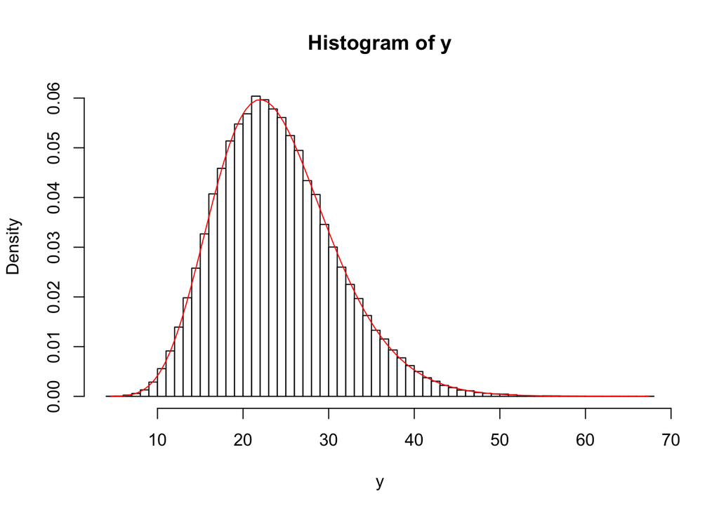

```r
y <- (25 - 1) * s2 / 2

hist(y, breaks = 50, probability = TRUE, col = "white")
curve(dchisq(x, df = 24),
      from = min(y), to = max(y), add = TRUE, col = "red")
```

Hopefully the answer is yes! Let’s see how well this works for another distribution. Below, re-run the simulation with a standard uniform from 0 to 1.

```r
# Question 02
N <- 100000
s2 <- rep(0, N)
for (j in seq_along(s2))
{
  x <- runif(n = 25, 0, 1)
  s2[j] <- var(x)
}
```

Now, create a histogram and overlay the expected chi-squared distribution. Make sure that you plug in the correct variance of the distribution when creating the variable `y`.

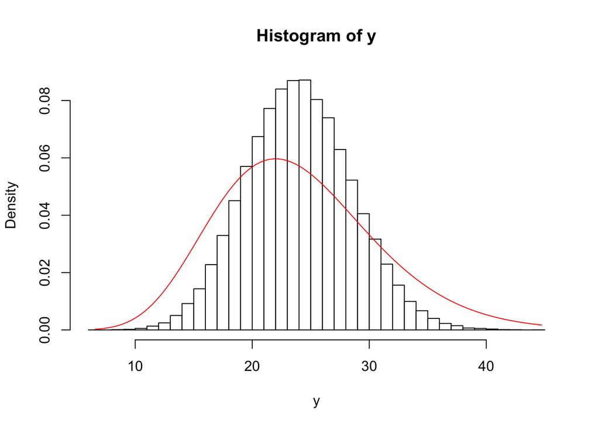

```r
# Question 03
y <- (25 - 1) * s2 / (1/12)

hist(y, breaks = 50, probability = TRUE, col = "white")
curve(dchisq(x, df = 24),
      from = min(y), to = max(y), add = TRUE, col = "red")
```

You will see that the distribution is not, in this case, a perfect match. So, keep in mind that the CLT needs to be used with caution when applied to non-normal data as it does not imply that the normal results immediately work for all other cases. We need to be careful about the assumptions and what we are measuring.

## Simulation of Student’s t-Distribution

We finish by quickly simulating Student’s t-Distribution. Here is a random simulation of an independent standard normal divided by a scaled chi-squared:

```r
N <- 100000
tstat <- rep(0, N)
for (j in seq_along(tstat))
{
  z <- rnorm(n = 1, mean = 0, sd = 1)
  c2 <- rchisq(n = 1, df = 10)
  tstat[j] <- z / sqrt(c2 / 10)
}
```

And here is the distribution compared to Student’s t-Distribution:

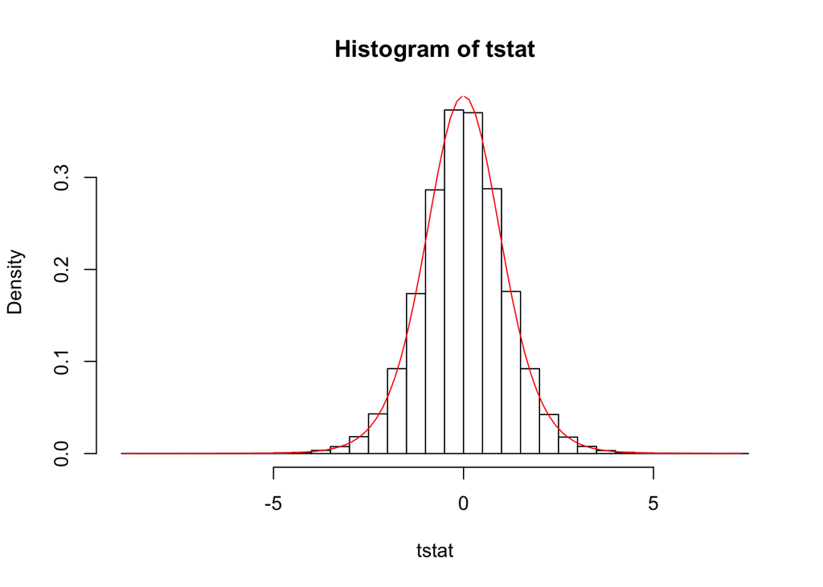

```r
hist(tstat, breaks = 50, probability = TRUE, col = "white")
curve(dt(x, df = 10),
      from = min(tstat), to = max(tstat), add = TRUE, col = "red")
```

We can also directly compare the t-Distribution to the normal distribution. Here is a plot of the densities with 10 degrees of freedom:

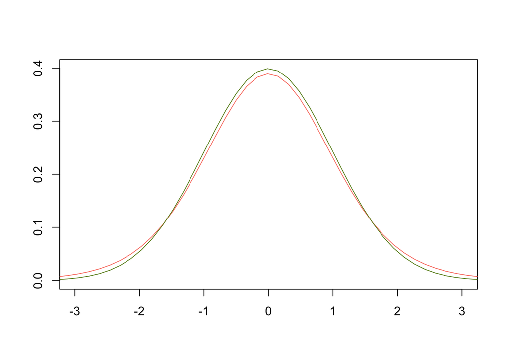

```r
plot(1, type="n", xlab="", ylab="", xlim=c(-3, 3), ylim=c(0, 0.4))
curve(dt(x, df = 10),
      from = min(tstat), to = max(tstat), add = TRUE, col = "salmon")
curve(dnorm(x, mean = 0, sd = 1),
      from = min(tstat), to = max(tstat), add = TRUE, col = "olivedrab")
```

Copy the code above in the block below and change the degrees of freedom. See what happens when it is very low (1 or 2). How many degrees of freedom do you need in order to no longer see a difference between the curves?

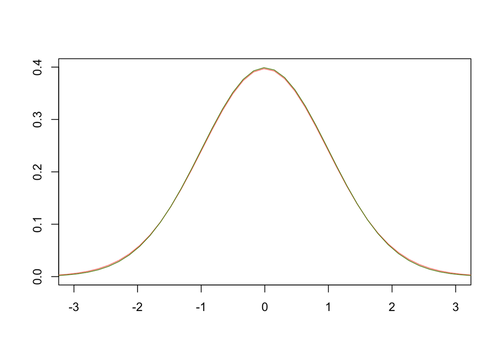

```r
# Question 04
# I can only barely see the two colors when df = 50
plot(1, type="n", xlab="", ylab="", xlim=c(-3, 3), ylim=c(0, 0.4))
curve(dt(x, df = 50),
      from = min(tstat), to = max(tstat), add = TRUE, col = "salmon")
curve(dnorm(x, mean = 0, sd = 1),
      from = min(tstat), to = max(tstat), add = TRUE, col = "olivedrab")
```